# Gene relevance based on multiple evidences in complex networks.

Noemi Di Nanni & Ettore Mosca

2019-05-8

## Description

This document describes the R package mND (Di Nanni et al. 2019), a new network diffusion based method for integrative multi-omics analysis.

## Installation

The package can be installed from within R:

```r
install.packages("igraph")
install.packages("/path_to_package/mND_xxx.tar.gz", repos = NULL)
library(mND)
```

## Input data

The package requires:

- An adjacency matrix ($A$) of undirected interaction network $G$;
- A score matrix $X0=[x_1, x_2, ..., x_L]$, in which each column $x_i$ (layer) represents a score vector over all vertices of $G$.
- The number of top k-neighbour to consider ($k$).

Optional arguments are:

- Number of permutations ($r$) of the input matrix;
- Number of cores ($cores$).

## Summary

All the analysis can be run using the following functions:

```r
W <- normalize_adj_mat(A)
X0_perm <- perm_X0(X0, r = 50, W)
Xs <- ND(X0_perm, W, cores = 4)
ind_adj <- neighbour_index(W)
mND_score <- mND(Xs, ind_adj, k = 3, cores = 4)
mND_score <- signif_assess(mND_score)
class_res <- classification(mND_score, X0, Hl, top, alpha)
plot_results(mND_score, class_res, W, n = 150, directory = "~/mND_results")
```

Most of the analyses can be easily carried out through the wrapper function `framework_mND`:

```r
W <- normalize_adj_mat(A)
mND_score <- framework_mND(X0, W, k = 3, r = 50, cores = 4)
class_res <- classification(mND_score, X0, Hl, top, alpha)
plot_results(mND_score, class_res, W, n = 150, directory = "~/mND_results")
```

## Case study: integration of mutation and expression changes in breast cancer

As proof of principle, mND is applied to find functionally related genes on the basis of gene mutations ($L_1$) and gene expression variation ($L_2$) in breast cancer (BC).

Somatic mutations and gene expression data from matched tumour-normal samples (blood for SM and solid tissue for GE) were collected from The Cancer Genome Atlas (TCGA) (Tomczak et al. 2015) for BC, using the R package TCGAbiolinks (Colaprico et al. 2015) and considering the human genome version 38 (hg38).

Mutation Annotation Format files were obtained from 4 pipelines: Muse (Fan et al. 2016), Mutect2 (Cibulskis et al. 2013), SomaticSniper (Larson et al. 2011), Varscan2 (Koboldt et al. 2012). Only mutation sites detected by at least two variant callers were considered. Gene mutation frequencies ($f$) were calculated as the fraction of subjects in which a gene was associated with at least one mutation.

Gene expression data were obtained using the TCGA workflow ``HTSeq-Counts’’. The R package limma (Ritchie et al. 2015) was used to normalize and quantify differential expression in matched tumor-normal samples, yielding log-fold changes, the corresponding p-values and FDRs (BH method).

Adjacency matrix ($A$) of undirected interaction network STRING (Szklarczyk et al. 2015) was used; $X0$ matrix was defined as the two column vectors: $x_1 = f$ and $x_2 = -log_{10}(FDR)$.

You can load $X0$ and $A$ as follows:

```r
library(mND)
data(X0)
head(X0,3) #L1: mutations, L2: gene expression variations
```

```
##        L1        L2
## FAM3C   0 0.5039283
## VTI1B   0 2.3264157
## MAGED2  0 3.1520429
```

```r
data(A) #adjacency matrix of STRING itnteractome
```

Let’s normalize the adjacency matrix $W$ and create 50 permutations of $X0$. The list X0_perm has 51 elements, the first is the input matrix $X0$, the others are its permutations; you can load precomputed permutations using `data(X0_perm)`, these permutations are obtained with seed equal to 2.

```r
library(mND)
W <- normalize_adj_mat(A)
X0_perm <- perm_X0(X0, r = 50, W, seed_n = 2)
```

Now, let’s apply network diffusion to our list X0_perm; you can load precomputed diffused scores using `data(Xs)`:

```r
library(mND)
Xs <- ND(X0_perm, W, cores = 4)
```

Network-diffusion, which quantifies the network proximity of each gene to other altered genes (positive elements of $x_1$ and $x_2$), transformed the input vector $x_1$ and $x_2$ into $x_1^*$ and $x_2^*$ respectively.

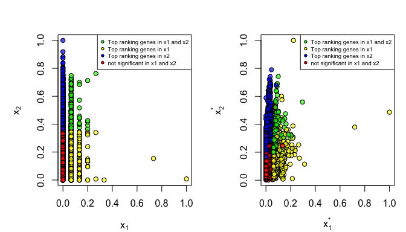

Let’s use the function `neighbour_index` to retrive the list of gene neighbours indexes from the adjacency matrix:

```r
library(mND)
ind_adj <- neighbour_index(W)
```

Now, we can apply `mND` function to find functionally related genes on the basis of $x_1^*$ and $x_2^*$ and their top $k$ neighbours; precomputed mND scores (calculated with $k = 3$) are included in mND package data (i.e. `data(mND_score)`). The value of $k$ can be optimised exploring the effect of values around 3 on the ranked gene list provided by mND in output (see the `optimize_k` function).

```r
library(mND)
mND_score <- mND(Xs, ind_adj, k=3, cores = 4)
```

Empirical $p$-values are calculated by using the pool of $r$ permutated versions of $X0$:

```r
library(mND)
mND_score <- signif_assess(mND_score)
```

Lastly, let’s classify genes in every layer. We define the set of the high scoring genes as:

- $H_1$: genes with a mutation frequency greater than zero;
- $H_2$: top 1200 differentially expressed genes (FDR < $10^-7$). Further, we set the cardinalities of gene sets $N_1$ and $N_2$, containing the genes with the highest scoring neighborhoods, as $|H_1|=|N_1|$ and $|H_2|=|N_2|$.

```r
library(mND)
data(X0)
Hl <- list(l1 = rownames(X0[X0[,1]>0,]),
           l2 = names(X0[order(X0[,2], decreasing = T),2][1:1200])
)
top_Nl <- unlist(lapply(Hl, function(x) length(x)))
top_Nl
```

```
##   l1   l2
## 1238 1200
```

```r
class_res <- classification(mND_score, X0, Hl, top = top_Nl)

#Classification of genes in every layer
head(class_res$gene_class)
```

```
##        L1 L2
## TP53    I  L
## TRIM28  M NS
## CCNB1   M  M
## RPS27A  M  L
## UBA52   M  L
## CCNA2   L  M
```

```r
#Occurrence of (M; L; I; NS) for each gene across layers
head(class_res$occ_labels)
```

```
##          I   L   M  NS
## TP53   0.5 0.5 0.0 0.0
## TRIM28 0.0 0.0 0.5 0.5
## CCNB1  0.0 0.0 1.0 0.0
## RPS27A 0.0 0.5 0.5 0.0
## UBA52  0.0 0.5 0.5 0.0
## CCNA2  0.0 0.5 0.5 0.0
```

A summary of previous results can be obtained with `plot_results` function, that gives in output the following plots:

- genes ranked by mND score and the corresponding p-value;
- gene networks composed of the top $n$ ranking genes;
- gene classification for the top 100 ranking genes across layers; legend: brown: isolated; orange: linker; purple: module; grey: not significant.

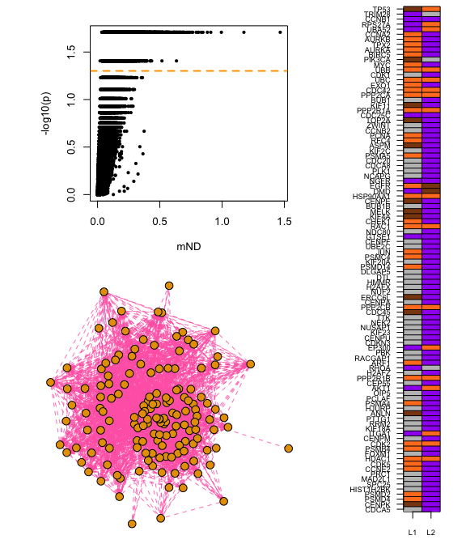

```r
library(mND)
plot_results(mND_score, class_res, W, n = 150, directory = "~/mND_results")
```

### Optimization of k value

An opportunity to optimize the value of $k$ relies in selecting a value that yields connected networks enriched in initial scores; the `optimize_k` function can be used for such objective.

Let’s use the `optimize_k` function to create a list with mND scores calculated for different $k$ values ($1 <= k <= 5$) and evaluate which value of $k$ yields connected networks enriched in initial scores. You can load precomputed results using `data(k_results)`.

```r
library(mND)

k_val <- seq(1,5,1)
k_results <- optimize_k(Xs, X0, k_val, ind_adj, W, top = 200, cores = 4)
```

$k = 3$ is a reasonable choice to obtain connected gene networks enriched in genes with the highest mutation frequencies and expression variations.

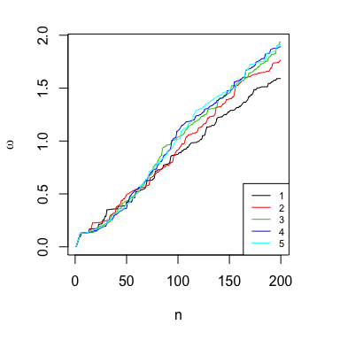

## References

Cibulskis et al. 2013. “Sensitive Detection of Somatic Point Mutations in Impure and Heterogeneous Cancer Samples.” Nature Biotechnology.

Colaprico et al. 2015. “TCGAbiolinks: An R/Bioconductor Package for Integrative Analysis of Tcga Data.” Nucleic Acids Research.

Di Nanni et al. 2019. “Gene Ranking by Multiple Evidences in Complex Networks.” R package version 0.1.0.

Fan et al. 2016. “MuSE: Accounting for Tumor Heterogeneity Using a Sample-Specific Error Model Improves Sensitivity and Specificity in Mutation Calling from Sequencing Data.” Genome Biology.

Koboldt et al. 2012. “Somatic Mutation and Copy Number Alteration Discovery in Cancer by Exome Sequencing.” Genome Res.

Larson et al. 2011. “SomaticSniper: Identification of Somatic Point Mutations in Whole Genome Sequencing Data.” Bioinformatics.

Ritchie et al. 2015. “Limma Powers Differential Expression Analyses for Rna-Sequencing and Microarray Studies.” Nucleic Acids Research.

Szklarczyk et al. 2015. “String V10: Protein-Protein Interaction Networks, Integrated over the Tree of Life.” Nucleic Acids Research.

Tomczak et al. 2015. “The Cancer Genome Atlas (Tcga): An Immeasurable Source of Knowledge.” Contemp Oncol (Pozn).